# Chapter 15

Paloma

2019-12-30

## Factors

Order of levels can be

- Arbitrary
- Principled: ordinal or ordered by the count

### Relevel by hand()

```r
labels <- c("Jan", "Mar", "Apr", "June", "Dec")
x1 <- c("Dec", "Apr", "Jan", "Mar", "June")

x1 <- enframe(x1) %>%
  mutate(value = fct_relevel(as_factor(value), labels))

levels(x1$value)
```

```
## [1] "Jan"  "Mar"  "Apr"  "June" "Dec"
```

```r
x1 <- tibble(
  month = rep(c("Dec", "Apr", "Jan", "June", "Mar"), times = 4),
  count = rnorm(20, mean = 50, sd = 20))

levels(x1$month)
```

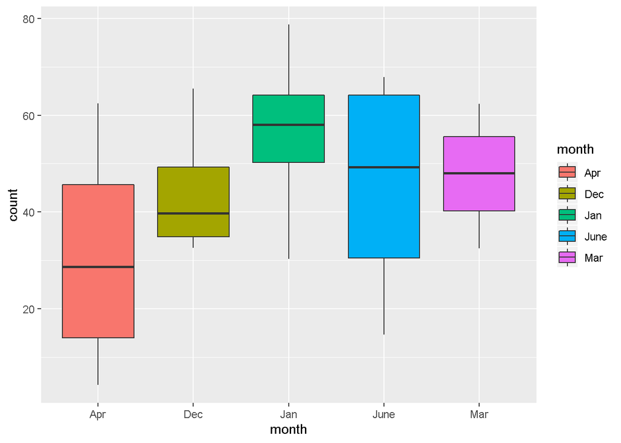

```r
x1 %>%
ggplot(aes(month, count, fill = month)) +
  geom_boxplot()
```

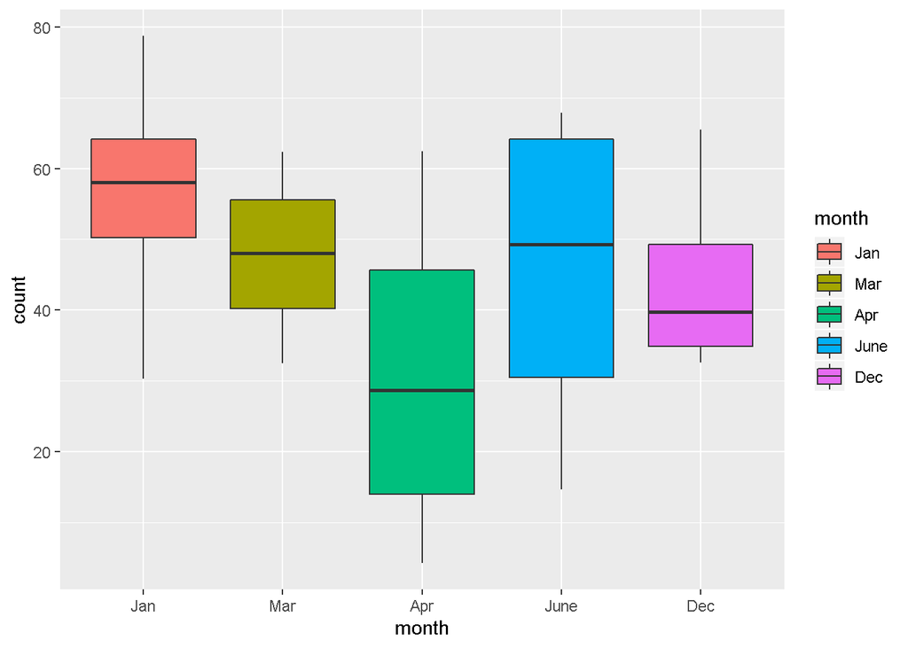

```r
x1 %>%
  mutate(month = fct_relevel(month, labels)) %>%
  ggplot(aes(month, count, fill = month)) +
  geom_boxplot()
```

We can also pull first one cathegory to the front

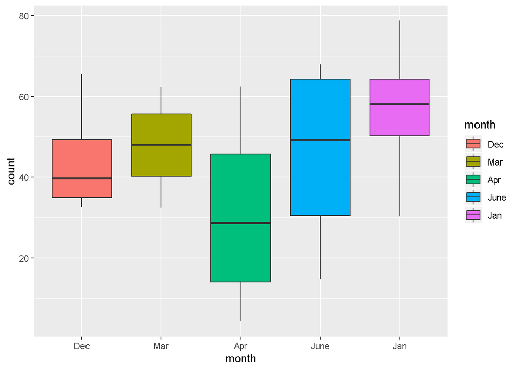

```r
x1 %>%
  mutate(month = fct_reorder(month, count)) %>%
  mutate(month = fct_relevel(month, c("Dec", "Mar"))) %>%
  ggplot(aes(month, count, fill = month)) +
  geom_boxplot()
```

Or to the back

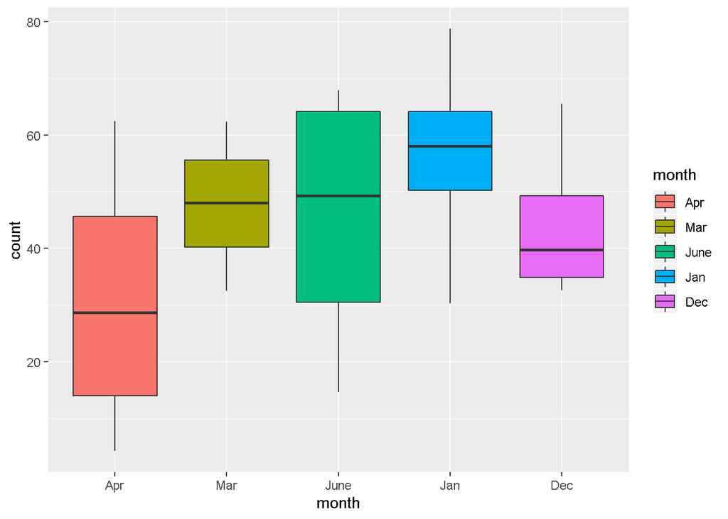

```r
x1 %>%
  mutate(month = fct_reorder(month, count)) %>%
  mutate(month = fct_relevel(month, "Dec", after = Inf)) %>%
  ggplot(aes(month, count, fill = month)) +
  geom_boxplot()
```

### Reorder by frequency (and reverse)

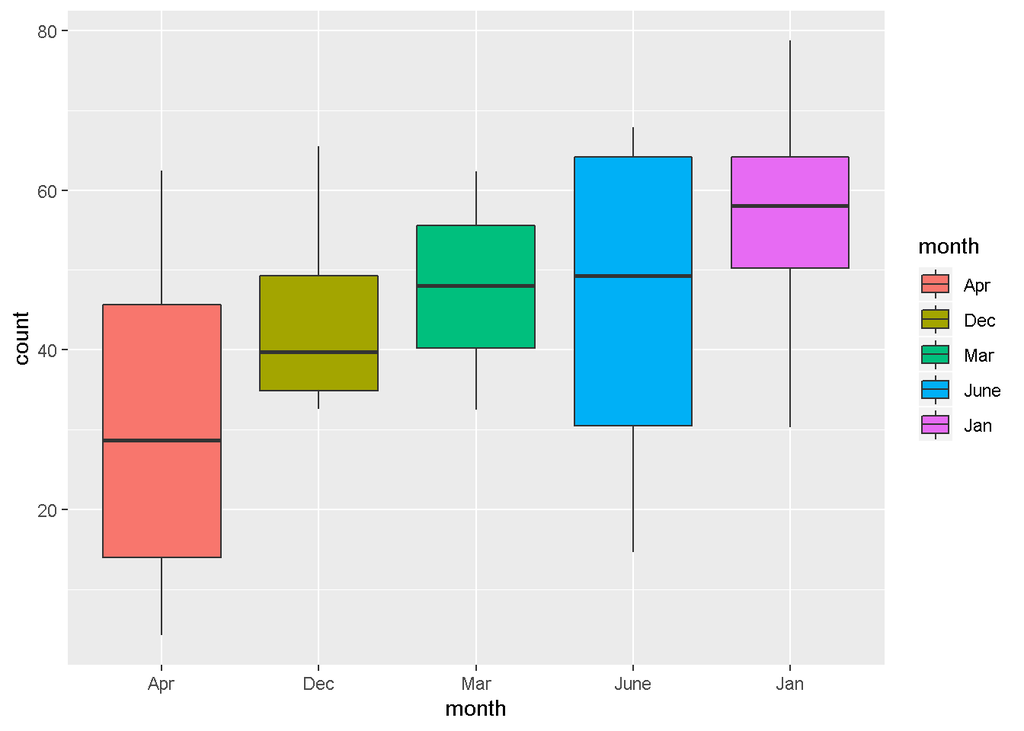

```r
x1 %>%
  mutate(month = fct_reorder(month, count)) %>%
  ggplot(aes(month, count, fill = month)) +
  geom_boxplot()
```

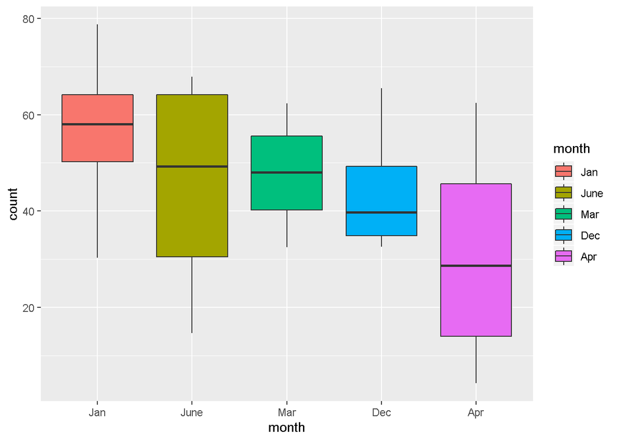

```r
x1 %>%
  mutate(month = fct_rev(fct_reorder(month, count))) %>%
  ggplot(aes(month, count, fill = month)) +
  geom_boxplot()
```

### Empty categories

Usually they are dropped if the cathegory doesn’t have any values, so we need to make it explicit

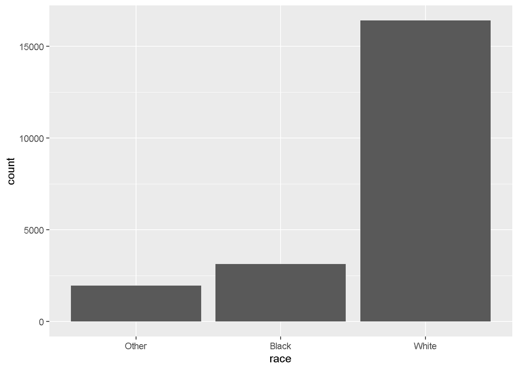

```r
forcats::gss_cat %>%
  ggplot(aes(race)) +
  geom_bar()
```

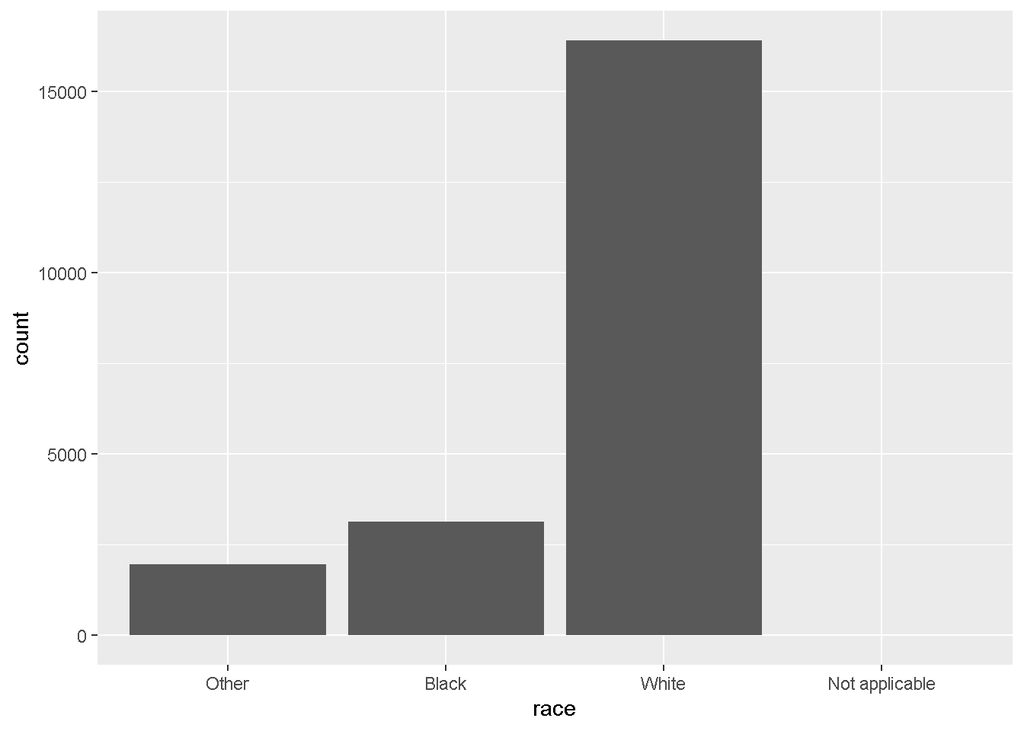

```r
forcats::gss_cat %>%
  ggplot(aes(race)) +
  geom_bar() +
  scale_x_discrete(drop = FALSE)
```

**Exercise**

Explore the distribution of rincome (reported income). What makes the default bar chart hard to understand? How could you improve the plot?

```r
df <- forcats::gss_cat

df %>%
  count(rincome) %>% mytable()
```

| rincome | n |
| --- | --- |
| No answer | 183 |
| Don’t know | 267 |
| Refused | 975 |
| $25000 or more | 7363 |
| $20000 - 24999 | 1283 |
| $15000 - 19999 | 1048 |
| $10000 - 14999 | 1168 |
| $8000 to 9999 | 340 |
| $7000 to 7999 | 188 |
| $6000 to 6999 | 215 |
| $5000 to 5999 | 227 |
| $4000 to 4999 | 226 |
| $3000 to 3999 | 276 |
| $1000 to 2999 | 395 |
| Lt $1000 | 286 |
| Not applicable | 7043 |

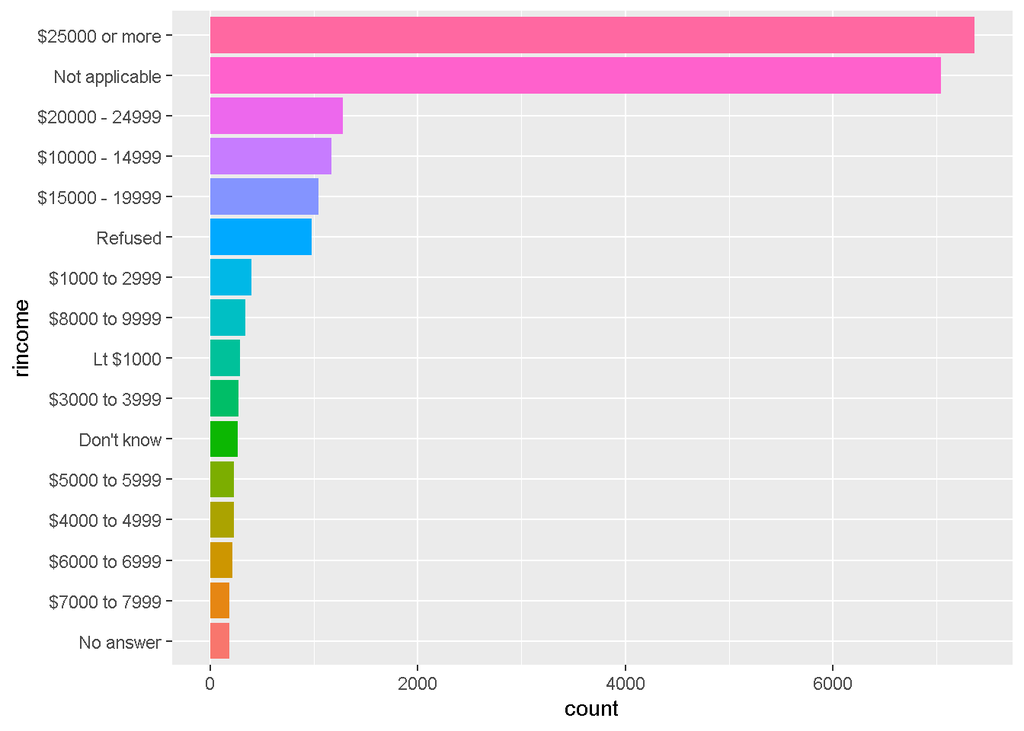

```r
df %>%
  group_by(rincome) %>%
  mutate(count_inc = n()) %>%
  ungroup() %>%
  mutate(rincome = fct_reorder(rincome, count_inc)) %>%
  ggplot(aes(rincome)) +
  geom_bar(aes(fill = rincome), show.legend = FALSE) +
  coord_flip()
```

What is the most common relig in this survey? What’s the most common partyid?

```r
df %>%
  count(relig, sort = TRUE) %>%
  slice(1) %>% mytable()
```

| relig | n |
| --- | --- |
| Protestant | 10846 |

```r
df %>%
  count(partyid, sort = TRUE) %>%
  slice(1) %>% mytable()
```

| partyid | n |
| --- | --- |
| Independent | 4119 |

Which relig does denom (denomination) apply to? How can you find out with a table? How can you find out with a visualization?

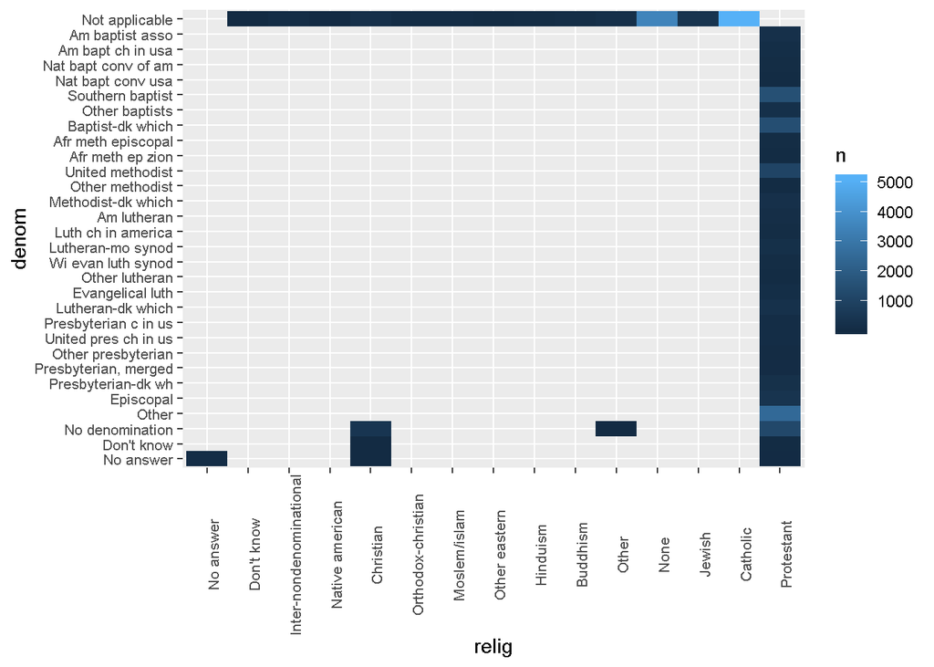

```r
df %>%
  count(relig, denom, sort = TRUE) %>%
  ggplot(aes(relig, denom)) +
  geom_tile(aes(fill = n)) +
  theme(axis.text.x = element_text(angle = 90, size = 8),
        axis.text.y = element_text(size = 8))
```

### Reorder2

Reorders the factor by the y values associated with the largest x values.

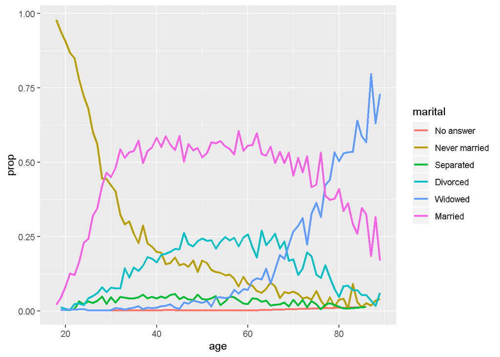

```r
age_marital <- df %>%
  filter(!is.na(age)) %>%
  count(age, marital) %>%
  group_by(age) %>%
  mutate(prop = n / sum(n))

age_marital %>%
  ggplot(aes(age, prop, color = marital)) +
  geom_line(size = 1)
```

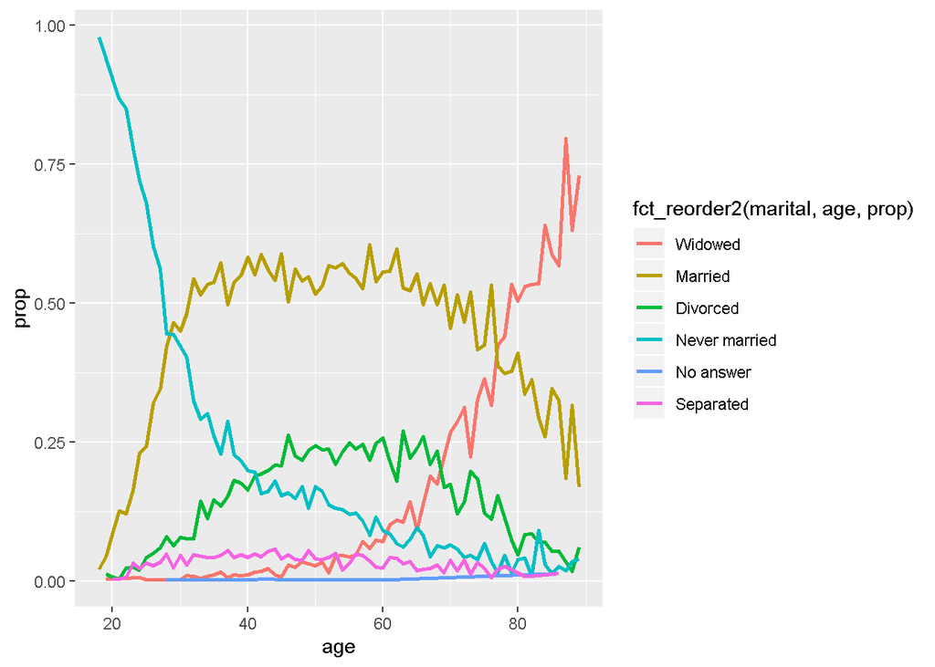

```r
age_marital %>%
  ggplot(aes(age, prop, color = fct_reorder2(marital, age, prop))) +
  geom_line(size = 1)
```

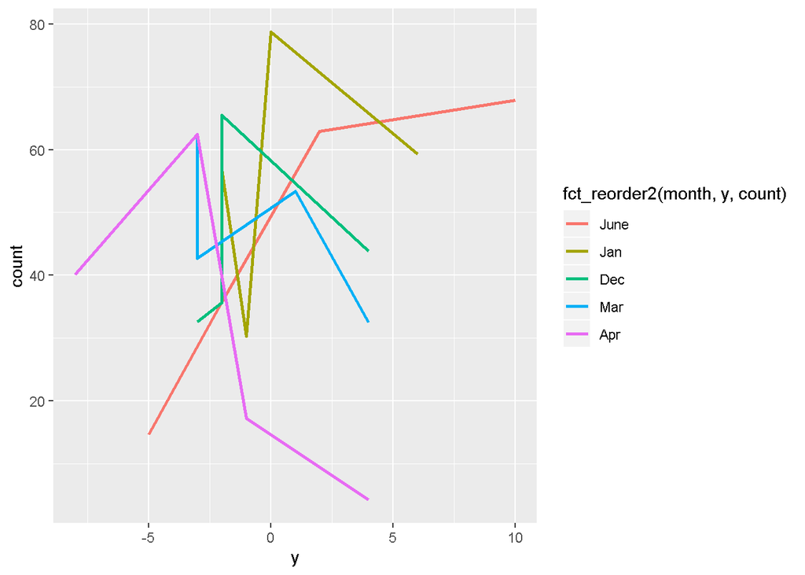

```r
x1 %>%
  mutate(y = round(rnorm(20, mean = 0, sd = 5), 0)) %>%
  ggplot(aes(y, count, color = fct_reorder2(month, y, count))) +
  geom_line(size = 1)
```

### In frequence: fct_infreq()

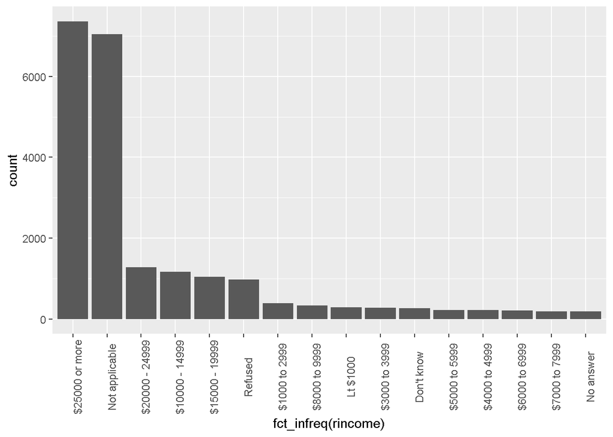

```r
df %>%
  ggplot(aes(fct_infreq(rincome))) +
  geom_bar() +
  theme(
    axis.text.x = element_text(angle = 90))
```

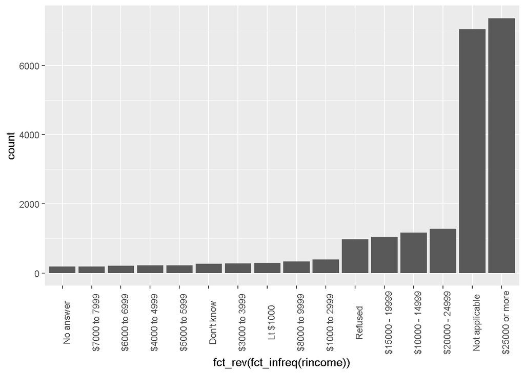

```r
df %>%
  ggplot(aes(fct_rev(fct_infreq(rincome)))) +
  geom_bar() +
  theme(
    axis.text.x = element_text(angle = 90))
```

**Exercises**

There are some suspiciously high numbers in tvhours. Is the mean a good summary?

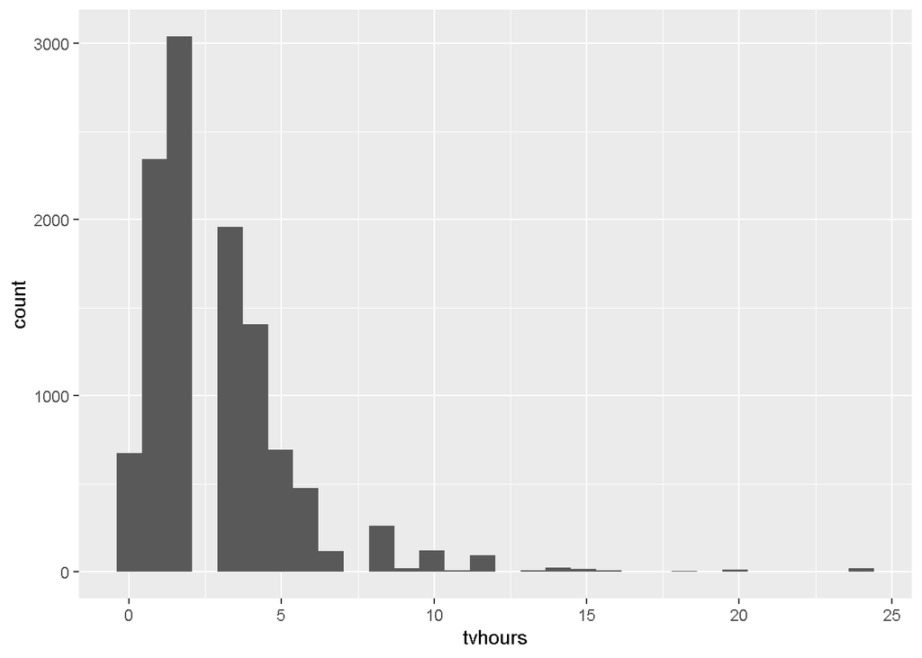

```r
df %>%
  ggplot(aes(tvhours)) +
  geom_histogram()
```

For each factor in gss_cat identify whether the order of the levels is arbitrary or principled.

```r
df %>%
  select_if(is.factor) %>%
  names()
```

```
## [1] "marital" "race"    "rincome" "partyid" "relig"   "denom"
```

### Recode

Allows to change the value of each level, factors don’t not work with `case_when`.

It leaves all unmentioned factors as they are.

```r
df %>%
  count(partyid) %>%
  head() %>% mytable()
```

| partyid | n |
| --- | --- |
| No answer | 154 |
| Don’t know | 1 |
| Other party | 393 |
| Strong republican | 2314 |
| Not str republican | 3032 |
| Ind,near rep | 1791 |

```r
df %>%
  mutate(partyid = case_when(
    partyid == "No answer" ~ "NoA",
    TRUE ~ partyid)) %>%
  count(partyid)
```

```
## Error: must be a character vector, not a `factor` object
```

```r
df %>%
  mutate(partyid = case_when(
    partyid == "No answer" ~ "NoA",
    TRUE ~ "Others")) %>%
  count(partyid)
```

```
## # A tibble: 2 x 2
##   partyid     n
##   <chr>   <int>
## 1 NoA       154
## 2 Others  21329
```

```r
df %>%
  mutate(partyid = fct_recode(partyid,
    "NoA" = "No answer")) %>%
  count(partyid) %>%
  head() %>% mytable
```

| partyid | n |
| --- | --- |
| NoA | 154 |
| Don’t know | 1 |
| Other party | 393 |
| Strong republican | 2314 |
| Not str republican | 3032 |
| Ind,near rep | 1791 |

### Collapse

```r
gss_cat %>%
count(rincome, sort = TRUE) %>%
  mutate(rincome = fct_collapse(rincome,
        "Not available" = c("Not applicable",
                            "Refused",
                            "Don't know",
                            "No answer"),
        "$1000 - 7999" = c("Lt $1000",
                           "$1000 to 2999",
                           "$3000 to 3999",
                           "$4000 to 4999",
                           "$5000 to 5999",
                           "$6000 to 6999",
                           "$7000 to 7999"))) %>%
  mytable()
```

| rincome | n |
| --- | --- |
| $25000 or more | 7363 |
| Not available | 7043 |
| $20000 - 24999 | 1283 |
| $10000 - 14999 | 1168 |
| $15000 - 19999 | 1048 |
| Not available | 975 |
| $1000 - 7999 | 395 |
| $8000 to 9999 | 340 |
| $1000 - 7999 | 286 |
| $1000 - 7999 | 276 |
| Not available | 267 |
| $1000 - 7999 | 227 |
| $1000 - 7999 | 226 |
| $1000 - 7999 | 215 |
| $1000 - 7999 | 188 |
| Not available | 183 |

### Lump

```r
df %>%
  mutate(rincome = fct_lump(rincome, n = 5)) %>%
  count(rincome)
```

```
## # A tibble: 6 x 2
##   rincome            n
##   <fct>          <int>
## 1 $25000 or more  7363
## 2 $20000 - 24999  1283
## 3 $15000 - 19999  1048
## 4 $10000 - 14999  1168
## 5 Not applicable  7043
## 6 Other           3578
```

**Exercises**

How have the proportions of people identifying as Democrat, Republican, and Independent changed over time?

```r
df %>%
  count(partyid)
```

```
## # A tibble: 10 x 2
##    partyid                n
##    <fct>              <int>
##  1 No answer            154
##  2 Don't know             1
##  3 Other party          393
##  4 Strong republican   2314
##  5 Not str republican  3032
##  6 Ind,near rep        1791
##  7 Independent         4119
##  8 Ind,near dem        2499
##  9 Not str democrat    3690
## 10 Strong democrat     3490
```

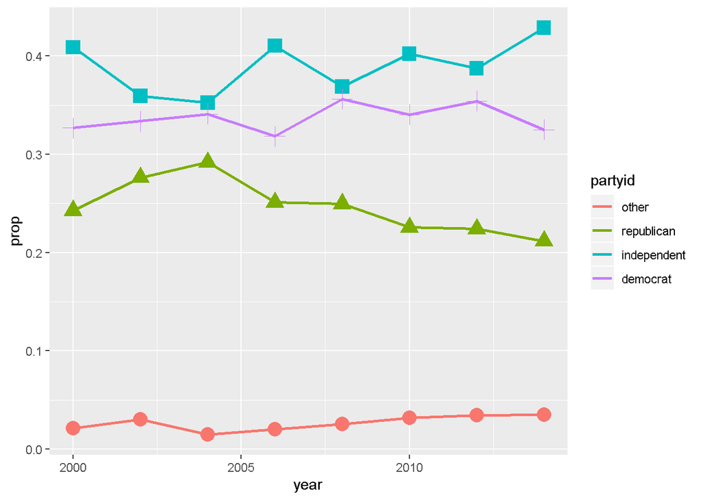

```r
df_clean <- df %>%
  select(year, partyid) %>%
  mutate(
    partyid = fct_collapse(partyid,
                         republican = c("Strong republican",
                                          "Not str republican"),
                         independent = c("Ind,near rep",
                                            "Independent",
                                           "Ind,near dem"),
                         democrat = c("Not str democrat",
                                        "Strong democrat"),
                         other = c("No answer",
                                     "Don't know",
                                     "Other party"))) %>%
  count(year, partyid)

df_clean %>%
  group_by(year) %>%
  mutate(total = sum(n),
         prop = n/total) %>%
  ungroup() %>%
  ggplot(aes(year, prop, color = partyid)) +
  geom_line(size = 1) +
  geom_point(aes(shape = partyid, size = 2), show.legend = FALSE)
```